# 05.Example 3

Modified

Su 2026-09-13 19:38

## Given:

To generate a power of $P_{gen} = 9\ \mathrm{W}$, the temperature of a fuel cell must be maintained at $T_c = 56.4\ \mathrm{°C}$, which requires removal of $11.25\ \mathrm{W}$ from the fuel cell and a cooling air velocity of $V = 9.4\ \frac{\mathrm{m}}{\mathrm{s}}$ for $T_\infty = 25\ \mathrm{°C}$. To provide these convective conditions, the fuel cell is centered in a $50\ \mathrm{mm} \times 26\ \mathrm{mm}$ rectangular duct, with $10\ \mathrm{mm}$ gaps between the exterior of the $50\ \mathrm{mm} \times 50\ \mathrm{mm} \times 6\ \mathrm{mm}$ fuel cell and the top and bottom of the well insulated duct wall. A small fan, powered by the fuel cell, is used to circulate the cooling air. Inspection of a particular fan vendor’s data sheets suggests that the ratio of the fan power consumption to the fan’s volumetric flow rate is $\frac{P_f}{V_f} = C = 1000\ \frac{\mathrm{s} \cdot \mathrm{W}}{\mathrm{m}^{3}}$ for the range of $10^{-4} \leq V_f \leq 10^{-2} \frac{m^3}{s}$.

Consider the effect of attaching an aluminum ($k = 200\ \frac{\mathrm{W}}{\left(\mathrm{K} \cdot \mathrm{m}\right)}$) finned heat sink, of identical top and bottom sections, onto the fuel cell body. The base of the heat sink is of thickness $t_b = 2\ \mathrm{mm}$. Each of the $N$ rectangular fins is of length $L_f = 8\ \mathrm{mm}$ and thickness $t_f = 1\ \mathrm{mm}$, and spans the entire length of the fuel cell, $L_c = 50\ \mathrm{mm}$. With the heat sink in place, radiation losses are negligible and the convective heat transfer coefficient may be related to the size and geometry of a typical air channel by an expression of the form $h = 1.78 k_{air} (\frac{L_f + a}{L_fa})$, where $a$ is the distance between fins.

## Required:

1. Determine the net electric power produced by the fuel cell fan system, $P_{net} = P_{gen} - P_f$.
2. Draw an equivalent thermal circuit for part 2 and determine the total number fins needed to reduce the fan power consumption to half of the value found in part 1.

## Solution:

Start first by defining all of the given values.

$$P_{gen} = 9\ \mathrm{W}$$
$$T_c = 56.4\ \mathrm{°C} = 329.55\ \mathrm{K}$$
$$q = 11.25\ \mathrm{W}$$
$$V = 9.4\ \frac{\mathrm{m}}{\mathrm{s}}$$
$$T_{\infty} = 25\ \mathrm{°C} = 298.15\ \mathrm{K}$$
$$W = 50\ \mathrm{mm}$$
$$H = 26\ \mathrm{mm}$$
$$t_g = 10\ \mathrm{mm}$$
$$W_c = 50\ \mathrm{mm}$$
$$L_c = 50\ \mathrm{mm}$$
$$t_c = 6\ \mathrm{mm}$$
$$C = 1000\ \frac{\mathrm{s} \cdot \mathrm{W}}{\mathrm{m}^{3}}$$
$$k_{al} = 200\ \frac{\mathrm{W}}{\left(\mathrm{K} \cdot \mathrm{m}\right)}$$
$$t_b = 2\ \mathrm{mm}$$
$$L_f = 8\ \mathrm{mm}$$
$$t_f = 1\ \mathrm{mm}$$

The thermal conductivity of air will also be needed. Going to table A.4 at $T = 300\ \mathrm{K}$ shows

$$k_{air} = 0.0263\ \frac{\mathrm{W}}{\left(\mathrm{K} \cdot \mathrm{m}\right)}$$

A sketch of the first arrangement is shown below.

Figure 1: System Sketch

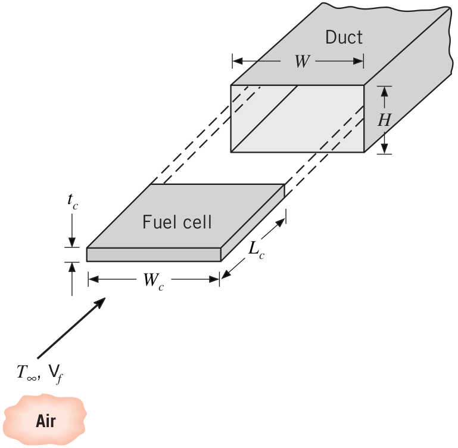

To determine the net power of the fan arrangement, the volumetric flow rate must be determined. The volumetric flow is found by first finding the cross sectional area of the flow. This is shown below

$$A_c = W (H - t_c) = 1000\ \mathrm{mm}^{2}$$

The volumetric flow rate is then

$$V_f = A_c V = 9400.0\ \frac{\mathrm{cm}^{3}}{\mathrm{s}}$$

The power of the fan is then

$$P_f = C V_f = 9.4\ \mathrm{W}$$

The net power is then

Answer (a): $P_{net} = P_{gen} - P_f = -0.4\ \mathrm{W}$

A sketch of the fin arrangement is shown below.

Figure 2: Fin Arrangement

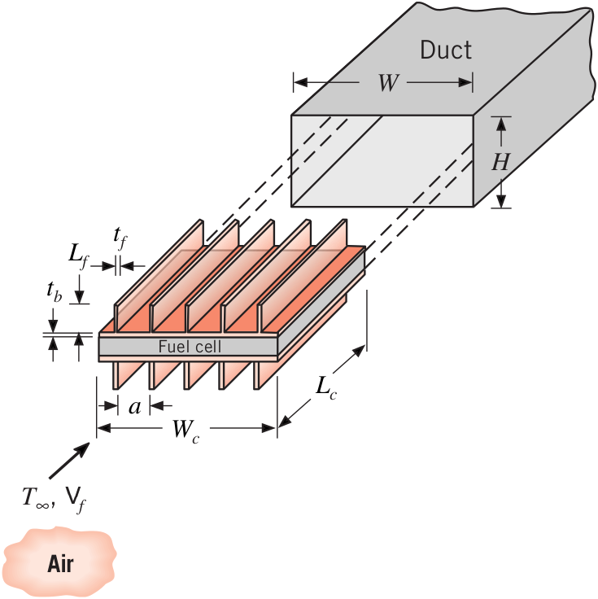

The thermal circuit of the fin arrangement is shown below.

Figure 3: Thermal Circuit, Answer (b1)

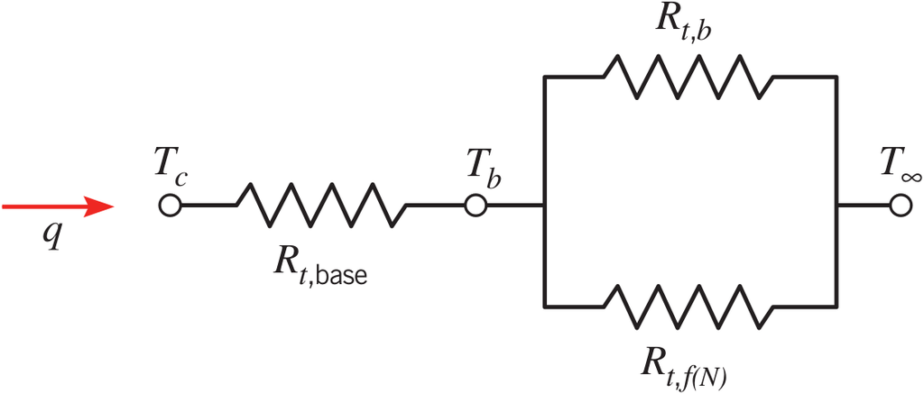

Before the circuit is analyzed, a few things need to discussed. There is no closed form solution to find the exact number of fins. Even if there were a closed form solution, a fin count $N$ that is something other than an integer is not reasonable. Since $N$ must be an integer (as well as an even integer because there are two sides; it would be strange to have different number of fins on each side), a guess and check method is a reasonable approach. Before the guess and check method begins, any parameter that is not dependent on the number of fins $N$ may first be determined. The first parameter that is not dependent on the number of fins $N$ is the thermal resistance of the base and is be found by

$$R_{t,base} = \frac{t_b}{k_{al} (2 L_c W_c)} = 2.0\ \frac{\mathrm{K}}{\mathrm{kW}}$$

The perimeter $P$ is independent of the number of fins $N$ and is found by

$$P = 2 (L_c + t_f) = 10.2\ \mathrm{cm}$$

The cross sectional area is also independent of $N$ and is found by

$$A_c = L_c t_f = 0.5\ \mathrm{cm}^{2}$$

These few parameters are the only ones that are independent of $N$. The number of fins may now be guess. This is shown below.

$$N = 20$$

The spacing between the fins may now be determined by

$$a = \frac{2 W_c - N t_f}{N} = 4.0\ \mathrm{mm}$$

The convective heat transfer coefficient may now be found by

$$h = 1.78 k_{air} \frac{L_f + a}{L_f a} = 17.56\ \frac{\mathrm{W}}{\left(\mathrm{K} \cdot \mathrm{m}^{2}\right)}$$

The $m$ term may be determined by

$$m = \sqrt{\frac{hP}{k_{al}A_c}} = 13.38\ \frac{1}{\mathrm{m}}$$

The thermal resistance of a single rectangular fin with convection occurring at the tip is given by

$$R_{t,f} = \frac{1}{\sqrt{h P k_{al} A_c} \tanh m L_f} = 70.07\ \frac{\mathrm{K}}{\mathrm{W}}$$

The total thermal resistance of all the fins is then

$$R_{t,f(N)} = \frac{R_{t,f}}{N} = 3.5\ \frac{\mathrm{K}}{\mathrm{W}}$$

The thermal resistance due to the convection of the unfinned portion is given by

$$R_{t,b} = \frac{1}{h (2 W_c - N t_f) L_c} = 14.24\ \frac{\mathrm{K}}{\mathrm{W}}$$

The total resistance of the circuit is then

$$R_{tot} = R_{t,base} + \frac{1}{\frac{1}{R_{t,b}}+\frac{1}{R_{t,f(N)}}} = 2.81\ \frac{\mathrm{K}}{\mathrm{W}}$$

The fuel cell temperature with this fin arrangement is found by

$$R_{tot}=\frac{T_c-T_\infty}{q}$$

Solving for $T_c$ shows

$$T_c^{\prime} = R_{tot} q+T_{\infty} = 329.8\ \mathrm{K} = 56.7\ \mathrm{°C}$$

Since this is higher than the desired temperature (i.e., $T_c^{\prime} = 56.7\ \mathrm{°C} \gt 56.4\ \mathrm{°C} = T_c$), more fins need to used. The number of fins can now be increase by $2$ and the process repeated. This is shown below.

$$N = 22$$

$$a = \frac{2 W_c - N t_f}{N} = 3.545\ \mathrm{mm}$$

$$h = 1.78 k_{air} \frac{L_f + a}{L_f a} = 19.06\ \frac{\mathrm{W}}{\left(\mathrm{K} \cdot \mathrm{m}^{2}\right)}$$

$$m = \sqrt{\frac{hP}{k_{al}A_c}} = 13.94\ \frac{1}{\mathrm{m}}$$

$$R_{t,f} = \frac{1}{\sqrt{h P k_{al} A_c} \tanh m L_f} = 64.58\ \frac{\mathrm{K}}{\mathrm{W}}$$

$$R_{t,f(N)} = \frac{R_{t,f}}{N} = 2.94\ \frac{\mathrm{K}}{\mathrm{W}}$$

$$R_{t,b} = \frac{1}{h (2 W_c - N t_f) L_c} = 13.46\ \frac{\mathrm{K}}{\mathrm{W}}$$

$$R_{tot} = R_{t,base} + \frac{1}{\frac{1}{R_{t,b}}+\frac{1}{R_{t,f(N)}}} = 2.41\ \frac{\mathrm{K}}{\mathrm{W}}$$

$$T_c^{\prime} = R_{tot} q+T_{\infty} = 325.3\ \mathrm{K} = 52.1\ \mathrm{°C}$$

Since this is lower than the desired temperature (i.e., $T_c^{\prime} = 52.1\ \mathrm{°C} \lt 56.4\ \mathrm{°C} = T_c$), and the previous guess resulted in a temperature higher than the desired temperature, a solution has been reached. Thus the required number of fins is

Answer (b2): $N = 22$